# Investigate a Dataset

## I am using the Baseball dataset (2016 version) for this project.

I will mention along the way which datasets specifically I am using.

## Questions I will investigate:

1) What is the relationship between the doubles and the triples of the players? 2) What is the relationship between the winning and losing pitches of the players? 3) What are the traits of the players with above average salaries?

## Start investigating question 1.

1) What is the relationship between the doubles and the triples of the players? We will use the Batting Table. The variables we investigate are "doubles" and "triples", noted as "2B" and "3B" respectively. These two variables are considered measures of batting performance. So it's interesting to observe the relationship between them.

```python
#We will use more datasets along this project.
#So we define a function to open our datasets as dataframes.

import pandas as pd

def pd_reader(file):
    return pd.read_csv(file, delimiter = ",")
```

```python
#Get the dataset "Batting" as a dataframe.
batting_df = pd_reader("Batting.csv")
```

```python
batting_df
```

|  | playerID | yearID | stint | teamID | lgID | G | AB | R | H | 2B | ... | RBI | SB | CS | BB | SO | IBB | HBP | SH | SF | GIDP |
| --- | --- | --- | --- | --- | --- | --- | --- | --- | --- | --- | --- | --- | --- | --- | --- | --- | --- | --- | --- | --- | --- |
| 0 | abercda01 | 1871 | 1 | TRO | NaN | 1 | 4 | 0 | 0 | 0 | ... | 0.0 | 0.0 | 0.0 | 0 | 0.0 | NaN | NaN | NaN | NaN | NaN |
| 1 | addybo01 | 1871 | 1 | RC1 | NaN | 25 | 118 | 30 | 32 | 6 | ... | 13.0 | 8.0 | 1.0 | 4 | 0.0 | NaN | NaN | NaN | NaN | NaN |
| 2 | allisar01 | 1871 | 1 | CL1 | NaN | 29 | 137 | 28 | 40 | 4 | ... | 19.0 | 3.0 | 1.0 | 2 | 5.0 | NaN | NaN | NaN | NaN | NaN |
| 3 | allisdo01 | 1871 | 1 | WS3 | NaN | 27 | 133 | 28 | 44 | 10 | ... | 27.0 | 1.0 | 1.0 | 0 | 2.0 | NaN | NaN | NaN | NaN | NaN |
| 4 | ansonca01 | 1871 | 1 | RC1 | NaN | 25 | 120 | 29 | 39 | 11 | ... | 16.0 | 6.0 | 2.0 | 2 | 1.0 | NaN | NaN | NaN | NaN | NaN |
| 5 | armstbo01 | 1871 | 1 | FW1 | NaN | 12 | 49 | 9 | 11 | 2 | ... | 5.0 | 0.0 | 1.0 | 0 | 1.0 | NaN | NaN | NaN | NaN | NaN |
| 6 | barkeal01 | 1871 | 1 | RC1 | NaN | 1 | 4 | 0 | 1 | 0 | ... | 2.0 | 0.0 | 0.0 | 1 | 0.0 | NaN | NaN | NaN | NaN | NaN |
| 7 | barnero01 | 1871 | 1 | BS1 | NaN | 31 | 157 | 66 | 63 | 10 | ... | 34.0 | 11.0 | 6.0 | 13 | 1.0 | NaN | NaN | NaN | NaN | NaN |
| 8 | barrebi01 | 1871 | 1 | FW1 | NaN | 1 | 5 | 1 | 1 | 1 | ... | 1.0 | 0.0 | 0.0 | 0 | 0.0 | NaN | NaN | NaN | NaN | NaN |
| 9 | barrofr01 | 1871 | 1 | BS1 | NaN | 18 | 86 | 13 | 13 | 2 | ... | 11.0 | 1.0 | 0.0 | 0 | 0.0 | NaN | NaN | NaN | NaN | NaN |
| 10 | bassjo01 | 1871 | 1 | CL1 | NaN | 22 | 89 | 18 | 27 | 1 | ... | 18.0 | 0.0 | 1.0 | 3 | 4.0 | NaN | NaN | NaN | NaN | NaN |
| 11 | battijo01 | 1871 | 1 | CL1 | NaN | 1 | 3 | 0 | 0 | 0 | ... | 0.0 | 0.0 | 0.0 | 1 | 0.0 | NaN | NaN | NaN | NaN | NaN |
| 12 | bealsto01 | 1871 | 1 | WS3 | NaN | 10 | 36 | 6 | 7 | 0 | ... | 1.0 | 2.0 | 0.0 | 2 | 0.0 | NaN | NaN | NaN | NaN | NaN |
| 13 | beaveed01 | 1871 | 1 | TRO | NaN | 3 | 15 | 7 | 6 | 0 | ... | 5.0 | 2.0 | 0.0 | 0 | 0.0 | NaN | NaN | NaN | NaN | NaN |
| 14 | bechtge01 | 1871 | 1 | PH1 | NaN | 20 | 94 | 24 | 33 | 9 | ... | 21.0 | 4.0 | 0.0 | 2 | 2.0 | NaN | NaN | NaN | NaN | NaN |
| 15 | bellast01 | 1871 | 1 | TRO | NaN | 29 | 128 | 26 | 32 | 3 | ... | 23.0 | 4.0 | 4.0 | 9 | 2.0 | NaN | NaN | NaN | NaN | NaN |
| 16 | berkena01 | 1871 | 1 | PH1 | NaN | 1 | 4 | 0 | 0 | 0 | ... | 0.0 | 0.0 | 0.0 | 0 | 3.0 | NaN | NaN | NaN | NaN | NaN |
| 17 | berryto01 | 1871 | 1 | PH1 | NaN | 1 | 4 | 0 | 1 | 0 | ... | 0.0 | 0.0 | 0.0 | 0 | 0.0 | NaN | NaN | NaN | NaN | NaN |
| 18 | berthha01 | 1871 | 1 | WS3 | NaN | 17 | 73 | 17 | 17 | 1 | ... | 8.0 | 3.0 | 1.0 | 4 | 2.0 | NaN | NaN | NaN | NaN | NaN |
| 19 | biermch01 | 1871 | 1 | FW1 | NaN | 1 | 2 | 0 | 0 | 0 | ... | 0.0 | 0.0 | 0.0 | 1 | 0.0 | NaN | NaN | NaN | NaN | NaN |
| 20 | birdge01 | 1871 | 1 | RC1 | NaN | 25 | 106 | 19 | 28 | 2 | ... | 13.0 | 1.0 | 0.0 | 3 | 2.0 | NaN | NaN | NaN | NaN | NaN |
| 21 | birdsda01 | 1871 | 1 | BS1 | NaN | 29 | 152 | 51 | 46 | 3 | ... | 24.0 | 6.0 | 0.0 | 4 | 4.0 | NaN | NaN | NaN | NaN | NaN |
| 22 | brainas01 | 1871 | 1 | WS3 | NaN | 30 | 134 | 24 | 30 | 4 | ... | 21.0 | 4.0 | 0.0 | 7 | 2.0 | NaN | NaN | NaN | NaN | NaN |
| 23 | brannmi01 | 1871 | 1 | CH1 | NaN | 3 | 14 | 2 | 1 | 0 | ... | 0.0 | 0.0 | 0.0 | 0 | 0.0 | NaN | NaN | NaN | NaN | NaN |
| 24 | burrohe01 | 1871 | 1 | WS3 | NaN | 12 | 63 | 11 | 15 | 2 | ... | 14.0 | 0.0 | 0.0 | 1 | 1.0 | NaN | NaN | NaN | NaN | NaN |
| 25 | careyto01 | 1871 | 1 | FW1 | NaN | 19 | 87 | 16 | 20 | 2 | ... | 10.0 | 5.0 | 0.0 | 2 | 1.0 | NaN | NaN | NaN | NaN | NaN |
| 26 | carleji01 | 1871 | 1 | CL1 | NaN | 29 | 127 | 31 | 32 | 8 | ... | 18.0 | 2.0 | 1.0 | 8 | 3.0 | NaN | NaN | NaN | NaN | NaN |
| 27 | conefr01 | 1871 | 1 | BS1 | NaN | 19 | 77 | 17 | 20 | 3 | ... | 16.0 | 12.0 | 1.0 | 8 | 2.0 | NaN | NaN | NaN | NaN | NaN |
| 28 | connone01 | 1871 | 1 | TRO | NaN | 7 | 33 | 6 | 7 | 0 | ... | 2.0 | 0.0 | 0.0 | 0 | 0.0 | NaN | NaN | NaN | NaN | NaN |
| 29 | cravebi01 | 1871 | 1 | TRO | NaN | 27 | 118 | 26 | 38 | 8 | ... | 26.0 | 6.0 | 3.0 | 3 | 0.0 | NaN | NaN | NaN | NaN | NaN |
| ... | ... | ... | ... | ... | ... | ... | ... | ... | ... | ... | ... | ... | ... | ... | ... | ... | ... | ... | ... | ... | ... |
| 102786 | wittgni01 | 2016 | 1 | MIA | NL | 48 | 0 | 0 | 0 | 0 | ... | 0.0 | 0.0 | 0.0 | 0 | 0.0 | 0.0 | 0.0 | 0.0 | 0.0 | 0.0 |
| 102787 | wolteto01 | 2016 | 1 | COL | NL | 71 | 205 | 27 | 53 | 15 | ... | 30.0 | 4.0 | 1.0 | 21 | 53.0 | 2.0 | 0.0 | 4.0 | 0.0 | 1.0 |
| 102788 | wongko01 | 2016 | 1 | SLN | NL | 121 | 313 | 39 | 75 | 7 | ... | 23.0 | 7.0 | 0.0 | 34 | 52.0 | 2.0 | 9.0 | 0.0 | 5.0 | 3.0 |
| 102789 | woodal02 | 2016 | 1 | LAN | NL | 15 | 16 | 2 | 4 | 0 | ... | 2.0 | 0.0 | 0.0 | 1 | 9.0 | 0.0 | 0.0 | 2.0 | 0.0 | 0.0 |
| 102790 | woodbl01 | 2016 | 1 | CIN | NL | 70 | 2 | 0 | 0 | 0 | ... | 0.0 | 0.0 | 0.0 | 0 | 2.0 | 0.0 | 0.0 | 0.0 | 0.0 | 0.0 |
| 102791 | woodtr01 | 2016 | 1 | CHN | NL | 81 | 11 | 0 | 2 | 0 | ... | 1.0 | 0.0 | 0.0 | 1 | 5.0 | 0.0 | 0.0 | 0.0 | 0.0 | 0.0 |
| 102792 | worleva01 | 2016 | 1 | BAL | AL | 35 | 0 | 0 | 0 | 0 | ... | 0.0 | 0.0 | 0.0 | 0 | 0.0 | 0.0 | 0.0 | 0.0 | 0.0 | 0.0 |
| 102793 | worthda01 | 2016 | 1 | HOU | AL | 16 | 39 | 4 | 7 | 2 | ... | 1.0 | 0.0 | 0.0 | 1 | 6.0 | 0.0 | 0.0 | 0.0 | 0.0 | 1.0 |
| 102794 | wrighda03 | 2016 | 1 | NYN | NL | 37 | 137 | 18 | 31 | 8 | ... | 14.0 | 3.0 | 2.0 | 26 | 55.0 | 0.0 | 0.0 | 0.0 | 0.0 | 0.0 |
| 102795 | wrighda04 | 2016 | 1 | CIN | NL | 4 | 5 | 0 | 0 | 0 | ... | 0.0 | 0.0 | 0.0 | 0 | 2.0 | 0.0 | 0.0 | 1.0 | 0.0 | 0.0 |
| 102796 | wrighda04 | 2016 | 2 | LAA | AL | 5 | 0 | 0 | 0 | 0 | ... | 0.0 | 0.0 | 0.0 | 0 | 0.0 | 0.0 | 0.0 | 0.0 | 0.0 | 0.0 |
| 102797 | wrighmi01 | 2016 | 1 | BAL | AL | 18 | 0 | 0 | 0 | 0 | ... | 0.0 | 0.0 | 0.0 | 0 | 0.0 | 0.0 | 0.0 | 0.0 | 0.0 | 0.0 |
| 102798 | wrighst01 | 2016 | 1 | BOS | AL | 25 | 4 | 0 | 0 | 0 | ... | 0.0 | 0.0 | 0.0 | 0 | 3.0 | 0.0 | 0.0 | 0.0 | 0.0 | 0.0 |
| 102799 | yateski01 | 2016 | 1 | NYA | AL | 41 | 0 | 0 | 0 | 0 | ... | 0.0 | 0.0 | 0.0 | 0 | 0.0 | 0.0 | 0.0 | 0.0 | 0.0 | 0.0 |
| 102800 | yelicch01 | 2016 | 1 | MIA | NL | 155 | 578 | 78 | 172 | 38 | ... | 98.0 | 9.0 | 4.0 | 72 | 138.0 | 4.0 | 4.0 | 0.0 | 5.0 | 20.0 |
| 102801 | ynoaga01 | 2016 | 1 | NYN | NL | 10 | 3 | 0 | 0 | 0 | ... | 0.0 | 0.0 | 0.0 | 0 | 0.0 | 0.0 | 0.0 | 0.0 | 0.0 | 0.0 |
| 102802 | ynoami01 | 2016 | 1 | CHA | AL | 23 | 0 | 0 | 0 | 0 | ... | 0.0 | 0.0 | 0.0 | 0 | 0.0 | 0.0 | 0.0 | 0.0 | 0.0 | 0.0 |
| 102803 | ynoara01 | 2016 | 1 | COL | NL | 3 | 5 | 0 | 0 | 0 | ... | 0.0 | 0.0 | 0.0 | 0 | 2.0 | 0.0 | 0.0 | 0.0 | 0.0 | 0.0 |
| 102804 | youngch03 | 2016 | 1 | KCA | AL | 34 | 1 | 0 | 0 | 0 | ... | 0.0 | 0.0 | 0.0 | 0 | 0.0 | 0.0 | 0.0 | 0.0 | 0.0 | 0.0 |
| 102805 | youngch04 | 2016 | 1 | BOS | AL | 76 | 203 | 29 | 56 | 18 | ... | 24.0 | 4.0 | 2.0 | 21 | 50.0 | 0.0 | 3.0 | 0.0 | 0.0 | 4.0 |
| 102806 | younger03 | 2016 | 1 | NYA | AL | 6 | 1 | 2 | 0 | 0 | ... | 0.0 | 1.0 | 0.0 | 0 | 0.0 | 0.0 | 0.0 | 0.0 | 0.0 | 0.0 |
| 102807 | youngma03 | 2016 | 1 | ATL | NL | 8 | 0 | 0 | 0 | 0 | ... | 0.0 | 0.0 | 0.0 | 0 | 0.0 | 0.0 | 0.0 | 0.0 | 0.0 | 0.0 |
| 102808 | zastrro01 | 2016 | 1 | CHN | NL | 8 | 3 | 0 | 0 | 0 | ... | 0.0 | 0.0 | 0.0 | 0 | 2.0 | 0.0 | 0.0 | 0.0 | 0.0 | 0.0 |
| 102809 | zieglbr01 | 2016 | 1 | ARI | NL | 36 | 0 | 0 | 0 | 0 | ... | 0.0 | 0.0 | 0.0 | 0 | 0.0 | 0.0 | 0.0 | 0.0 | 0.0 | 0.0 |
| 102810 | zieglbr01 | 2016 | 2 | BOS | AL | 33 | 0 | 0 | 0 | 0 | ... | 0.0 | 0.0 | 0.0 | 0 | 0.0 | 0.0 | 0.0 | 0.0 | 0.0 | 0.0 |
| 102811 | zimmejo02 | 2016 | 1 | DET | AL | 19 | 4 | 0 | 1 | 0 | ... | 0.0 | 0.0 | 0.0 | 0 | 2.0 | 0.0 | 0.0 | 1.0 | 0.0 | 0.0 |
| 102812 | zimmery01 | 2016 | 1 | WAS | NL | 115 | 427 | 60 | 93 | 18 | ... | 46.0 | 4.0 | 1.0 | 29 | 104.0 | 1.0 | 5.0 | 0.0 | 6.0 | 12.0 |
| 102813 | zobribe01 | 2016 | 1 | CHN | NL | 147 | 523 | 94 | 142 | 31 | ... | 76.0 | 6.0 | 4.0 | 96 | 82.0 | 6.0 | 4.0 | 4.0 | 4.0 | 17.0 |
| 102814 | zuninmi01 | 2016 | 1 | SEA | AL | 55 | 164 | 16 | 34 | 7 | ... | 31.0 | 0.0 | 0.0 | 21 | 65.0 | 0.0 | 6.0 | 0.0 | 1.0 | 0.0 |
| 102815 | zychto01 | 2016 | 1 | SEA | AL | 12 | 0 | 0 | 0 | 0 | ... | 0.0 | 0.0 | 0.0 | 0 | 0.0 | 0.0 | 0.0 | 0.0 | 0.0 | 0.0 |

102816 rows × 22 columns

We will investigate this dataset first. We will look for missing values and potential outliers for our variables of interest.

```python
#Since we will check for missing values in upcoming datasets as well, let's define a function for that.
def is_null(df):
    return df.isnull().sum()
```

```python
is_null(batting_df["2B"])
```

```
0
```

```python
is_null(batting_df["3B"])
```

```
0
```

We used pandas functionality to check if we have missing values for our variables of interest. In both cases, we do not have any missing values. Let's have a look at the boxplots of these variables to check for outliers.

```python
import matplotlib.pyplot as plt
import seaborn as sns
%matplotlib inline
```

```python
#We select and name the variables we need.

doubles = batting_df["2B"]
triples = batting_df["3B"]
```

```python
#We will plot histograms for other variables as well, so let's define a function for that.
def plt_hist(var, bins, title, xlabel, ylabel):
    plt.hist(var, bins)
    plt.title(title, color="red", size=20)
    plt.xlabel(xlabel)
    plt.ylabel(ylabel)
```

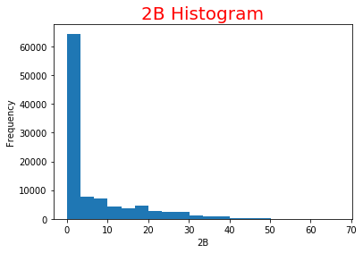

```python
plt_hist(doubles, 20, "2B Histogram", "2B", "Frequency")
```

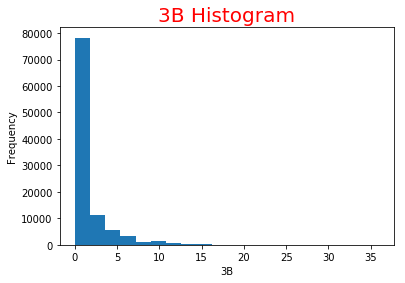

```python
plt_hist(triples, 20, "3B Histogram", "3B", "Frequency")
```

```python
batting_df.describe()
```

|  | yearID | stint | G | AB | R | H | 2B | 3B | HR | RBI | SB | CS | BB | SO | IBB | HBP | SH | SF | GIDP |
| --- | --- | --- | --- | --- | --- | --- | --- | --- | --- | --- | --- | --- | --- | --- | --- | --- | --- | --- | --- |
| count | 102816.000000 | 102816.000000 | 102816.000000 | 102816.000000 | 102816.000000 | 102816.000000 | 102816.000000 | 102816.000000 | 102816.000000 | 102392.000000 | 101516.000000 | 79360.000000 | 102816.000000 | 94978.000000 | 66251.000000 | 100006.000000 | 96478.000000 | 66782.000000 | 76706.000000 |
| mean | 1964.262313 | 1.077838 | 51.343439 | 141.905511 | 18.815544 | 37.139930 | 6.289167 | 1.293252 | 2.813599 | 17.003975 | 2.976821 | 1.226008 | 13.067207 | 20.529712 | 1.105870 | 1.056057 | 2.299540 | 1.054101 | 2.981018 |
| std | 38.856297 | 0.284366 | 47.121658 | 184.654492 | 28.242983 | 52.603757 | 9.662468 | 2.645770 | 6.304919 | 26.352011 | 7.717174 | 2.747377 | 20.746460 | 28.328542 | 2.780187 | 2.276251 | 4.241095 | 1.961732 | 4.735153 |
| min | 1871.000000 | 1.000000 | 1.000000 | 0.000000 | 0.000000 | 0.000000 | 0.000000 | 0.000000 | 0.000000 | 0.000000 | 0.000000 | 0.000000 | 0.000000 | 0.000000 | 0.000000 | 0.000000 | 0.000000 | 0.000000 | 0.000000 |
| 25% | 1934.000000 | 1.000000 | 13.000000 | 4.000000 | 0.000000 | 0.000000 | 0.000000 | 0.000000 | 0.000000 | 0.000000 | 0.000000 | 0.000000 | 0.000000 | 1.000000 | 0.000000 | 0.000000 | 0.000000 | 0.000000 | 0.000000 |
| 50% | 1973.000000 | 1.000000 | 34.000000 | 49.000000 | 4.000000 | 9.000000 | 1.000000 | 0.000000 | 0.000000 | 3.000000 | 0.000000 | 0.000000 | 3.000000 | 9.000000 | 0.000000 | 0.000000 | 0.000000 | 0.000000 | 0.000000 |
| 75% | 1998.000000 | 1.000000 | 80.000000 | 231.000000 | 27.000000 | 58.000000 | 9.000000 | 1.000000 | 2.000000 | 24.000000 | 2.000000 | 1.000000 | 18.000000 | 29.000000 | 1.000000 | 1.000000 | 3.000000 | 1.000000 | 4.000000 |
| max | 2016.000000 | 5.000000 | 165.000000 | 716.000000 | 192.000000 | 262.000000 | 67.000000 | 36.000000 | 73.000000 | 191.000000 | 138.000000 | 42.000000 | 232.000000 | 223.000000 | 120.000000 | 51.000000 | 67.000000 | 19.000000 | 36.000000 |

Both distributions of "2B" and "3B" are right-skewed. In both cases, the mean values are very far from the corresponding maximum values, which implies that there are outliers.

Check some general statistics of our dataset. We focus on "2B" and "3B". We can see that the values of "2B" range from 0 to 67 units, with a mean of 6.29 units and standard deviation of 9.66 units. The values of "3B" range from 0 to 36 units, with a mean of 1.29 units and standard deviation of 2.64 units.

Notice that the doubles are triples are shown for a certain year, for a certain player.

```python
#We compute the correlation between the two variables by using the numpy functionality.

import numpy as np

np.corrcoef(doubles, triples)
```

```
array([[ 1.        ,  0.65655829],
       [ 0.65655829,  1.        ]])
```

The correlation we found is 0.656. It is a positive, pretty strong correlation. This result indicates that as a player performs more doubles, he tends to perform more triples as well. Notice that this is just exploratory analysis. We do not infer any causal effect. We cannot say that performing more doubles causes a player to perform more triples. For that we would have to compute a regression analysis, while controlling for many intervening variables.

```python
#Let's define a function for the scatterplots we will graph.

def plt_scatter(var1, var2, s, title, xlabel, ylabel):
    plt.scatter(var1, var2, s)
    plt.title(title, color="red", size=20)
    plt.xlabel(xlabel)
    plt.ylabel(ylabel)
```

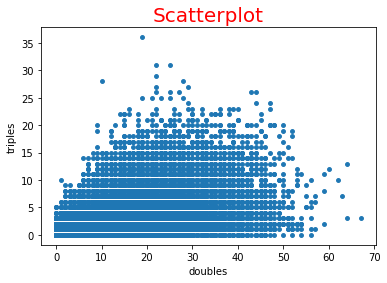

```python
plt_scatter(doubles, triples, 15, "Scatterplot", "doubles", "triples")
```

Here we are plotting a scatterplot of the doubles and triples, to show visually the correlation. The x-axis represents the doubles, and the y-axis represents the triples. We are relatively far from having a diagonal line (representing perfect correlation). However we can notice that as values for doubles increase, values for triples tend to increase as well.

## Now we will investigate question 2.

2) What is the relationship between the winning and losing pitches of the players? We will use the same method. Get the dataframe, and use the statistics from there to compute the correlation between the two variables.

Notice that the winning and losing pitches are shown for a given year, for a given player.

```python
#Get the dataset "Pitching" as a dataframe.
pitching_df = pd_reader("Pitching.csv")
```

```python
#This is the dataframe we will be working with.
#We are interested in "W" (winning pitches) and "L" (losing pitches).

pitching_df
```

|  | playerID | yearID | stint | teamID | lgID | W | L | G | GS | CG | ... | IBB | WP | HBP | BK | BFP | GF | R | SH | SF | GIDP |
| --- | --- | --- | --- | --- | --- | --- | --- | --- | --- | --- | --- | --- | --- | --- | --- | --- | --- | --- | --- | --- | --- |
| 0 | bechtge01 | 1871 | 1 | PH1 | NaN | 1 | 2 | 3 | 3 | 2 | ... | NaN | NaN | NaN | 0 | NaN | NaN | 42 | NaN | NaN | NaN |
| 1 | brainas01 | 1871 | 1 | WS3 | NaN | 12 | 15 | 30 | 30 | 30 | ... | NaN | NaN | NaN | 0 | NaN | NaN | 292 | NaN | NaN | NaN |
| 2 | fergubo01 | 1871 | 1 | NY2 | NaN | 0 | 0 | 1 | 0 | 0 | ... | NaN | NaN | NaN | 0 | NaN | NaN | 9 | NaN | NaN | NaN |
| 3 | fishech01 | 1871 | 1 | RC1 | NaN | 4 | 16 | 24 | 24 | 22 | ... | NaN | NaN | NaN | 0 | NaN | NaN | 257 | NaN | NaN | NaN |
| 4 | fleetfr01 | 1871 | 1 | NY2 | NaN | 0 | 1 | 1 | 1 | 1 | ... | NaN | NaN | NaN | 0 | NaN | NaN | 21 | NaN | NaN | NaN |
| 5 | flowedi01 | 1871 | 1 | TRO | NaN | 0 | 0 | 1 | 0 | 0 | ... | NaN | NaN | NaN | 0 | NaN | NaN | 0 | NaN | NaN | NaN |
| 6 | mackde01 | 1871 | 1 | RC1 | NaN | 0 | 1 | 3 | 1 | 1 | ... | NaN | NaN | NaN | 0 | NaN | NaN | 30 | NaN | NaN | NaN |
| 7 | mathebo01 | 1871 | 1 | FW1 | NaN | 6 | 11 | 19 | 19 | 19 | ... | NaN | NaN | NaN | 2 | NaN | NaN | 243 | NaN | NaN | NaN |
| 8 | mcbridi01 | 1871 | 1 | PH1 | NaN | 18 | 5 | 25 | 25 | 25 | ... | NaN | NaN | NaN | 0 | NaN | NaN | 223 | NaN | NaN | NaN |
| 9 | mcmuljo01 | 1871 | 1 | TRO | NaN | 12 | 15 | 29 | 29 | 28 | ... | NaN | NaN | NaN | 0 | NaN | NaN | 362 | NaN | NaN | NaN |
| 10 | meyerle01 | 1871 | 1 | PH1 | NaN | 0 | 0 | 1 | 0 | 0 | ... | NaN | NaN | NaN | 0 | NaN | NaN | 1 | NaN | NaN | NaN |
| 11 | paborch01 | 1871 | 1 | CL1 | NaN | 0 | 2 | 7 | 1 | 1 | ... | NaN | NaN | NaN | 0 | NaN | NaN | 53 | NaN | NaN | NaN |
| 12 | pinkhed01 | 1871 | 1 | CH1 | NaN | 1 | 0 | 3 | 0 | 0 | ... | NaN | NaN | NaN | 0 | NaN | NaN | 8 | NaN | NaN | NaN |
| 13 | prattal01 | 1871 | 1 | CL1 | NaN | 10 | 17 | 28 | 28 | 22 | ... | NaN | NaN | NaN | 0 | NaN | NaN | 288 | NaN | NaN | NaN |
| 14 | spaldal01 | 1871 | 1 | BS1 | NaN | 19 | 10 | 31 | 31 | 22 | ... | NaN | NaN | NaN | 0 | NaN | NaN | 272 | NaN | NaN | NaN |
| 15 | stearbi01 | 1871 | 1 | WS3 | NaN | 2 | 0 | 2 | 2 | 2 | ... | NaN | NaN | NaN | 0 | NaN | NaN | 11 | NaN | NaN | NaN |
| 16 | woltery01 | 1871 | 1 | NY2 | NaN | 16 | 16 | 32 | 32 | 31 | ... | NaN | NaN | NaN | 0 | NaN | NaN | 283 | NaN | NaN | NaN |
| 17 | wrighha01 | 1871 | 1 | BS1 | NaN | 1 | 0 | 9 | 0 | 0 | ... | NaN | NaN | NaN | 0 | NaN | NaN | 31 | NaN | NaN | NaN |
| 18 | zettlge01 | 1871 | 1 | CH1 | NaN | 18 | 9 | 28 | 28 | 25 | ... | NaN | NaN | NaN | 0 | NaN | NaN | 233 | NaN | NaN | NaN |
| 19 | bentlcy01 | 1872 | 1 | MID | NaN | 2 | 15 | 18 | 17 | 16 | ... | NaN | NaN | NaN | 0 | NaN | NaN | 252 | NaN | NaN | NaN |
| 20 | brainas01 | 1872 | 1 | WS3 | NaN | 2 | 7 | 9 | 9 | 9 | ... | NaN | NaN | NaN | 0 | NaN | NaN | 140 | NaN | NaN | NaN |
| 21 | brainas01 | 1872 | 2 | MID | NaN | 0 | 2 | 2 | 2 | 1 | ... | NaN | NaN | NaN | 0 | NaN | NaN | 17 | NaN | NaN | NaN |
| 22 | brittji01 | 1872 | 1 | BR2 | NaN | 9 | 28 | 37 | 37 | 37 | ... | NaN | NaN | NaN | 1 | NaN | NaN | 473 | NaN | NaN | NaN |
| 23 | buttefr01 | 1872 | 1 | MID | NaN | 3 | 2 | 6 | 5 | 5 | ... | NaN | NaN | NaN | 0 | NaN | NaN | 78 | NaN | NaN | NaN |
| 24 | cummica01 | 1872 | 1 | NY2 | NaN | 33 | 20 | 55 | 55 | 53 | ... | NaN | NaN | NaN | 0 | NaN | NaN | 347 | NaN | NaN | NaN |
| 25 | fishech01 | 1872 | 1 | BL1 | NaN | 10 | 1 | 19 | 11 | 9 | ... | NaN | NaN | NaN | 0 | NaN | NaN | 78 | NaN | NaN | NaN |
| 26 | malonma01 | 1872 | 1 | BR1 | NaN | 0 | 3 | 3 | 3 | 3 | ... | NaN | NaN | NaN | 0 | NaN | NaN | 86 | NaN | NaN | NaN |
| 27 | martiph01 | 1872 | 1 | TRO | NaN | 1 | 2 | 8 | 3 | 0 | ... | NaN | NaN | NaN | 0 | NaN | NaN | 59 | NaN | NaN | NaN |
| 28 | martiph01 | 1872 | 2 | BR1 | NaN | 2 | 7 | 10 | 9 | 9 | ... | NaN | NaN | NaN | 0 | NaN | NaN | 106 | NaN | NaN | NaN |
| 29 | mathebo01 | 1872 | 1 | BL1 | NaN | 25 | 18 | 49 | 47 | 39 | ... | NaN | NaN | NaN | 0 | NaN | NaN | 356 | NaN | NaN | NaN |
| ... | ... | ... | ... | ... | ... | ... | ... | ... | ... | ... | ... | ... | ... | ... | ... | ... | ... | ... | ... | ... | ... |
| 44933 | wilheto01 | 2016 | 1 | TEX | AL | 2 | 3 | 21 | 0 | 0 | ... | 0.0 | 0.0 | 2.0 | 0 | 109.0 | 3.0 | 25 | 0.0 | 1.0 | 4.0 |
| 44934 | wilheto01 | 2016 | 2 | SEA | AL | 0 | 1 | 29 | 0 | 0 | ... | 0.0 | 0.0 | 0.0 | 0 | 100.0 | 2.0 | 10 | 0.0 | 0.0 | 4.0 |
| 44935 | willije02 | 2016 | 1 | SLN | NL | 0 | 0 | 11 | 0 | 0 | ... | 1.0 | 0.0 | 2.0 | 0 | 81.0 | 9.0 | 15 | 0.0 | 1.0 | 3.0 |
| 44936 | willitr01 | 2016 | 1 | PIT | NL | 1 | 1 | 7 | 1 | 0 | ... | 0.0 | 0.0 | 0.0 | 0 | 61.0 | 1.0 | 13 | 0.0 | 0.0 | 2.0 |
| 44937 | wilsoal01 | 2016 | 1 | DET | AL | 4 | 0 | 62 | 0 | 0 | ... | 5.0 | 2.0 | 1.0 | 0 | 297.0 | 6.0 | 26 | 0.0 | 5.0 | 8.0 |
| 44938 | wilsoju10 | 2016 | 1 | DET | AL | 4 | 5 | 66 | 0 | 0 | ... | 2.0 | 4.0 | 1.0 | 0 | 251.0 | 10.0 | 29 | 1.0 | 0.0 | 7.0 |
| 44939 | wilsoty01 | 2016 | 1 | BAL | AL | 4 | 6 | 24 | 13 | 0 | ... | 1.0 | 2.0 | 4.0 | 0 | 414.0 | 5.0 | 57 | 1.0 | 3.0 | 8.0 |
| 44940 | wimmeal01 | 2016 | 1 | MIN | AL | 1 | 3 | 16 | 0 | 0 | ... | 1.0 | 0.0 | 0.0 | 0 | 72.0 | 2.0 | 8 | 0.0 | 2.0 | 3.0 |
| 44941 | winklda01 | 2016 | 1 | ATL | NL | 0 | 0 | 3 | 0 | 0 | ... | 0.0 | 0.0 | 0.0 | 0 | 8.0 | 0.0 | 0 | 0.0 | 0.0 | 0.0 |
| 44942 | wislema01 | 2016 | 1 | ATL | NL | 7 | 13 | 27 | 26 | 0 | ... | 3.0 | 5.0 | 4.0 | 1 | 671.0 | 1.0 | 90 | 2.0 | 3.0 | 12.0 |
| 44943 | withrch01 | 2016 | 1 | ATL | NL | 3 | 0 | 46 | 0 | 0 | ... | 1.0 | 1.0 | 2.0 | 0 | 158.0 | 6.0 | 16 | 2.0 | 1.0 | 2.0 |
| 44944 | wittgni01 | 2016 | 1 | MIA | NL | 4 | 3 | 48 | 0 | 0 | ... | 2.0 | 1.0 | 1.0 | 0 | 213.0 | 9.0 | 18 | 3.0 | 2.0 | 2.0 |
| 44945 | woodal02 | 2016 | 1 | LAN | NL | 1 | 4 | 14 | 10 | 0 | ... | 0.0 | 4.0 | 3.0 | 0 | 255.0 | 0.0 | 30 | 0.0 | 2.0 | 5.0 |
| 44946 | woodbl01 | 2016 | 1 | CIN | NL | 6 | 5 | 70 | 0 | 0 | ... | 3.0 | 8.0 | 2.0 | 0 | 330.0 | 21.0 | 38 | 1.0 | 2.0 | 8.0 |
| 44947 | woodtr01 | 2016 | 1 | CHN | NL | 4 | 0 | 77 | 0 | 0 | ... | 2.0 | 0.0 | 1.0 | 0 | 252.0 | 16.0 | 24 | 1.0 | 0.0 | 3.0 |
| 44948 | worleva01 | 2016 | 1 | BAL | AL | 2 | 2 | 35 | 4 | 0 | ... | 0.0 | 3.0 | 3.0 | 0 | 365.0 | 13.0 | 37 | 0.0 | 3.0 | 12.0 |
| 44949 | wrighda04 | 2016 | 1 | CIN | NL | 0 | 2 | 4 | 2 | 0 | ... | 0.0 | 1.0 | 0.0 | 0 | 64.0 | 0.0 | 16 | 1.0 | 1.0 | 2.0 |
| 44950 | wrighda04 | 2016 | 2 | LAA | AL | 1 | 3 | 5 | 5 | 0 | ... | 0.0 | 1.0 | 5.0 | 0 | 115.0 | 0.0 | 16 | 1.0 | 1.0 | 4.0 |
| 44951 | wrighmi01 | 2016 | 1 | BAL | AL | 3 | 4 | 18 | 12 | 0 | ... | 0.0 | 2.0 | 9.0 | 0 | 328.0 | 5.0 | 53 | 1.0 | 5.0 | 10.0 |
| 44952 | wrighst01 | 2016 | 1 | BOS | AL | 13 | 6 | 24 | 24 | 4 | ... | 1.0 | 10.0 | 8.0 | 0 | 656.0 | 0.0 | 74 | 2.0 | 2.0 | 16.0 |
| 44953 | yateski01 | 2016 | 1 | NYA | AL | 2 | 1 | 41 | 0 | 0 | ... | 1.0 | 1.0 | 4.0 | 0 | 184.0 | 11.0 | 24 | 1.0 | 1.0 | 1.0 |
| 44954 | ynoaga01 | 2016 | 1 | NYN | NL | 1 | 0 | 10 | 3 | 0 | ... | 0.0 | 0.0 | 1.0 | 0 | 88.0 | 2.0 | 13 | 0.0 | 2.0 | 1.0 |
| 44955 | ynoami01 | 2016 | 1 | CHA | AL | 1 | 0 | 23 | 0 | 0 | ... | 2.0 | 4.0 | 5.0 | 0 | 135.0 | 7.0 | 11 | 1.0 | 2.0 | 1.0 |
| 44956 | youngch03 | 2016 | 1 | KCA | AL | 3 | 9 | 34 | 13 | 0 | ... | 1.0 | 3.0 | 1.0 | 0 | 406.0 | 7.0 | 63 | 0.0 | 4.0 | 3.0 |
| 44957 | youngma03 | 2016 | 1 | ATL | NL | 0 | 0 | 8 | 0 | 0 | ... | 0.0 | 0.0 | 1.0 | 0 | 37.0 | 1.0 | 5 | 1.0 | 1.0 | 0.0 |
| 44958 | zastrro01 | 2016 | 1 | CHN | NL | 1 | 0 | 8 | 1 | 0 | ... | 0.0 | 0.0 | 1.0 | 0 | 66.0 | 1.0 | 3 | 0.0 | 2.0 | 1.0 |
| 44959 | zieglbr01 | 2016 | 1 | ARI | NL | 2 | 3 | 36 | 0 | 0 | ... | 5.0 | 0.0 | 2.0 | 0 | 165.0 | 30.0 | 13 | 1.0 | 1.0 | 10.0 |
| 44960 | zieglbr01 | 2016 | 2 | BOS | AL | 2 | 4 | 33 | 0 | 0 | ... | 2.0 | 1.0 | 1.0 | 0 | 124.0 | 12.0 | 8 | 1.0 | 0.0 | 6.0 |
| 44961 | zimmejo02 | 2016 | 1 | DET | AL | 9 | 7 | 19 | 18 | 0 | ... | 0.0 | 3.0 | 2.0 | 0 | 450.0 | 1.0 | 63 | 1.0 | 5.0 | 8.0 |
| 44962 | zychto01 | 2016 | 1 | SEA | AL | 1 | 0 | 12 | 0 | 0 | ... | 2.0 | 0.0 | 1.0 | 0 | 60.0 | 3.0 | 6 | 0.0 | 1.0 | 1.0 |

44963 rows × 30 columns

We will investigate this dataset. We will look for missing values and potential outliers in our variables of interest.

```python
is_null(pitching_df["W"])
```

```
0
```

```python
is_null(pitching_df["L"])
```

```
0
```

We have no missing values in our variables of interest. Let's plot their distribution to check for potential outliers.

```python
#Let's select and name our variables of interest.

wins = pitching_df["W"]
losses = pitching_df["L"]
```

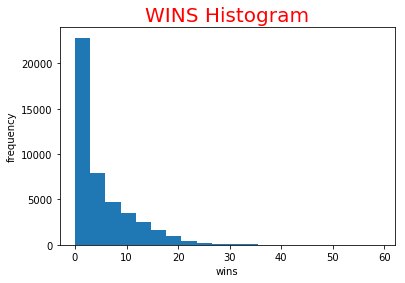

```python
plt_hist(wins, 20, "WINS Histogram", "wins", "frequency")
```

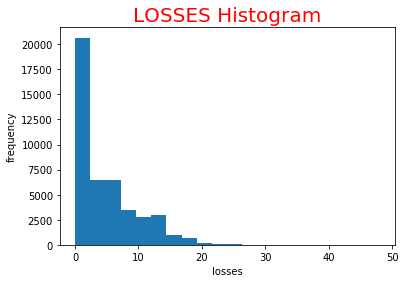

```python
plt_hist(losses, 20, "LOSSES Histogram", "losses", "frequency")
```

```python
pitching_df.describe()
```

|  | yearID | stint | W | L | G | GS | CG | SHO | SV | IPouts | ... | IBB | WP | HBP | BK | BFP | GF | R | SH | SF | GIDP |
| --- | --- | --- | --- | --- | --- | --- | --- | --- | --- | --- | --- | --- | --- | --- | --- | --- | --- | --- | --- | --- | --- |
| count | 44963.000000 | 44963.000000 | 44963.000000 | 44963.000000 | 44963.000000 | 44963.000000 | 44963.000000 | 44963.000000 | 44963.000000 | 44963.000000 | ... | 30388.000000 | 44830.000000 | 44405.000000 | 44963.000000 | 44724.000000 | 44830.000000 | 44963.000000 | 12063.000000 | 12063.000000 | 12061.000000 |
| mean | 1968.670062 | 1.079643 | 4.715744 | 4.715722 | 23.681761 | 9.485488 | 3.151035 | 0.448591 | 1.504793 | 253.872139 | ... | 2.411379 | 2.528575 | 2.266096 | 0.301604 | 343.312181 | 6.345260 | 43.021773 | 2.141922 | 1.878388 | 5.322610 |
| std | 37.569499 | 0.284834 | 5.813410 | 4.988846 | 18.493488 | 12.283920 | 7.081844 | 1.109742 | 4.991518 | 257.330446 | ... | 2.772648 | 3.425706 | 2.998881 | 0.755523 | 348.758261 | 9.993949 | 43.245812 | 2.710191 | 2.121352 | 5.990178 |
| min | 1871.000000 | 1.000000 | 0.000000 | 0.000000 | 1.000000 | 0.000000 | 0.000000 | 0.000000 | 0.000000 | 0.000000 | ... | 0.000000 | 0.000000 | 0.000000 | 0.000000 | 0.000000 | 0.000000 | 0.000000 | 0.000000 | 0.000000 | 0.000000 |
| 25% | 1941.000000 | 1.000000 | 0.000000 | 1.000000 | 7.000000 | 0.000000 | 0.000000 | 0.000000 | 0.000000 | 49.000000 | ... | 0.000000 | 0.000000 | 0.000000 | 0.000000 | 64.000000 | 0.000000 | 11.000000 | 0.000000 | 0.000000 | 1.000000 |
| 50% | 1978.000000 | 1.000000 | 2.000000 | 3.000000 | 21.000000 | 3.000000 | 0.000000 | 0.000000 | 0.000000 | 167.000000 | ... | 2.000000 | 1.000000 | 1.000000 | 0.000000 | 227.000000 | 3.000000 | 28.000000 | 1.000000 | 1.000000 | 3.000000 |
| 75% | 2001.000000 | 1.000000 | 7.000000 | 8.000000 | 35.000000 | 17.000000 | 3.000000 | 0.000000 | 1.000000 | 393.000000 | ... | 4.000000 | 4.000000 | 3.000000 | 0.000000 | 535.000000 | 8.000000 | 67.000000 | 3.000000 | 3.000000 | 8.000000 |
| max | 2016.000000 | 4.000000 | 59.000000 | 48.000000 | 106.000000 | 75.000000 | 75.000000 | 16.000000 | 62.000000 | 2040.000000 | ... | 23.000000 | 63.000000 | 41.000000 | 16.000000 | 2906.000000 | 84.000000 | 519.000000 | 21.000000 | 14.000000 | 40.000000 |

8 rows × 27 columns

Let's give some visual graphs to our variables, to see that their distributions are indeed very similar.

Indeed both distribution are very similar, namely they are right-skewed. In both cases, the mean values are very far from the maximum values. This means that we have outliers.

```python
#Compute the correlation.

np.corrcoef(wins, losses)
```

```
array([[ 1.       ,  0.7418541],
       [ 0.7418541,  1.       ]])
```

The correlation between the winning and losing pitches of the players is 0.74. It is a positive and strong correlation. Recall that this is only exploratory analysis. All we can say is that as the number of winning pitches increases, the number of losing pitches tends to increase as well. This makes sense because there are more pitches that a player executes throughout all the games in a given year. So it is quite likely to have successful pitches ("wins") and unsuccessful ones ("losses") in a given year.

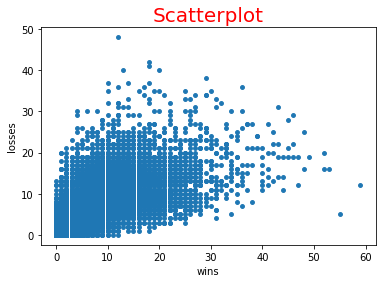

```python
plt_scatter(wins, losses, 15, "Scatterplot", "wins", "losses")
```

We will give a visual representation of this correlation, with a scatterplot. The x-axis represents the wins, and the y-axis represents the losses. Here we can see a more clear pattern of positive correlation than in the previous scatterplot. It is more contrasted that as the values for wins increases, the values for losses tends to increase as well.

## Now we will investigate question 3.

What are the traits of the players with the highest salaries? We will use as the traits the performance measures we've just worked with (doubles, triples, wins and losses). First we need the dataset with the salaries.

```python
#Get the dataset "Salaries" as a dataframe.
salaries_df = pd_reader("Salaries.csv")
```

```python
salaries_df
```

|  | yearID | teamID | lgID | playerID | salary |
| --- | --- | --- | --- | --- | --- |
| 0 | 1985 | ATL | NL | barkele01 | 870000 |
| 1 | 1985 | ATL | NL | bedrost01 | 550000 |
| 2 | 1985 | ATL | NL | benedbr01 | 545000 |
| 3 | 1985 | ATL | NL | campri01 | 633333 |
| 4 | 1985 | ATL | NL | ceronri01 | 625000 |
| 5 | 1985 | ATL | NL | chambch01 | 800000 |
| 6 | 1985 | ATL | NL | dedmoje01 | 150000 |
| 7 | 1985 | ATL | NL | forstte01 | 483333 |
| 8 | 1985 | ATL | NL | garbege01 | 772000 |
| 9 | 1985 | ATL | NL | harpete01 | 250000 |
| 10 | 1985 | ATL | NL | hornebo01 | 1500000 |
| 11 | 1985 | ATL | NL | hubbagl01 | 455000 |
| 12 | 1985 | ATL | NL | mahleri01 | 407500 |
| 13 | 1985 | ATL | NL | mcmurcr01 | 275000 |
| 14 | 1985 | ATL | NL | mumphje01 | 775000 |
| 15 | 1985 | ATL | NL | murphda05 | 1625000 |
| 16 | 1985 | ATL | NL | oberkke01 | 616667 |
| 17 | 1985 | ATL | NL | perezpa01 | 450000 |
| 18 | 1985 | ATL | NL | perryge01 | 120000 |
| 19 | 1985 | ATL | NL | ramirra01 | 750000 |
| 20 | 1985 | ATL | NL | suttebr01 | 1354167 |
| 21 | 1985 | ATL | NL | washicl01 | 800000 |
| 22 | 1985 | BAL | AL | boddimi01 | 625000 |
| 23 | 1985 | BAL | AL | dauerri01 | 480000 |
| 24 | 1985 | BAL | AL | davisst02 | 437500 |
| 25 | 1985 | BAL | AL | dempsri01 | 512500 |
| 26 | 1985 | BAL | AL | dwyerji01 | 375000 |
| 27 | 1985 | BAL | AL | flanami01 | 641667 |
| 28 | 1985 | BAL | AL | fordda01 | 450000 |
| 29 | 1985 | BAL | AL | grosswa01 | 483333 |
| ... | ... | ... | ... | ... | ... |
| 26398 | 2016 | TOR | AL | stromma01 | 515900 |
| 26399 | 2016 | TOR | AL | tholejo01 | 800000 |
| 26400 | 2016 | TOR | AL | travide01 | 511200 |
| 26401 | 2016 | TOR | AL | tulowtr01 | 20000000 |
| 26402 | 2016 | WSN | NL | barreaa01 | 519400 |
| 26403 | 2016 | WSN | NL | belisma01 | 1250000 |
| 26404 | 2016 | WSN | NL | drewst01 | 3000000 |
| 26405 | 2016 | WSN | NL | espinda01 | 2875000 |
| 26406 | 2016 | WSN | NL | gonzagi01 | 12100000 |
| 26407 | 2016 | WSN | NL | harpebr03 | 5000000 |
| 26408 | 2016 | WSN | NL | heisech01 | 1250000 |
| 26409 | 2016 | WSN | NL | kellesh01 | 4000000 |
| 26410 | 2016 | WSN | NL | lobatjo01 | 1387500 |
| 26411 | 2016 | WSN | NL | murphda08 | 8000000 |
| 26412 | 2016 | WSN | NL | papeljo01 | 10936574 |
| 26413 | 2016 | WSN | NL | perezol01 | 3000000 |
| 26414 | 2016 | WSN | NL | petityu01 | 2500000 |
| 26415 | 2016 | WSN | NL | ramoswi01 | 5350000 |
| 26416 | 2016 | WSN | NL | rendoan01 | 2800000 |
| 26417 | 2016 | WSN | NL | reverbe01 | 6250000 |
| 26418 | 2016 | WSN | NL | riverfe01 | 516100 |
| 26419 | 2016 | WSN | NL | roarkta01 | 543400 |
| 26420 | 2016 | WSN | NL | robincl01 | 534900 |
| 26421 | 2016 | WSN | NL | rossjo01 | 514400 |
| 26422 | 2016 | WSN | NL | scherma01 | 22142857 |
| 26423 | 2016 | WSN | NL | strasst01 | 10400000 |
| 26424 | 2016 | WSN | NL | taylomi02 | 524000 |
| 26425 | 2016 | WSN | NL | treinbl01 | 524900 |
| 26426 | 2016 | WSN | NL | werthja01 | 21733615 |
| 26427 | 2016 | WSN | NL | zimmery01 | 14000000 |

26428 rows × 5 columns

Again we will check for missing values and potential outliers.

```python
is_null(salaries_df["salary"])
```

```
0
```

There are no missing salaries. We will now plot the distribution of the salaries.

```python
salaries = salaries_df["salary"]
```

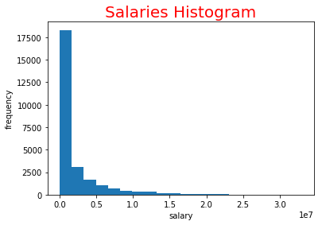

```python
plt_hist(salaries, 20, "Salaries Histogram", "salary", "frequency")
```

```python
salaries_df["salary"].describe()
```

```
count    2.642800e+04
mean     2.085634e+06
std      3.455348e+06
min      0.000000e+00
25%      2.947020e+05
50%      5.500000e+05
75%      2.350000e+06
max      3.300000e+07
Name: salary, dtype: float64
```

We look at the statistics of the salaries in our dataset. Notice the notation of the values. For instance, for the mean, the ("+06") means that we move the comma six places to the right to get the value. To see that number more clearly, we select it separately in the next cell.

```python
salaries_df["salary"].mean()
```

```
2085634.053125473
```

Since we are interested in the players with above average salaries, we need to know the average first. The average salary is 2 085 634.053 dollars.

```python
salaries_df["salary"].max()
```

```
33000000
```

It's interesting to observe the highest salary as well. It is 33 000 000 dollars.

We already worked with performance measures of the players, namely their doubles and triples in batting; and winning and losing pitches. Let's filter these variables for the players that earn above average salaries and see what performance measures they have.

First we will merge the tables we've been using so far, selecting only the variables of interest.

```python
#We are selecting only the variables 2B and 3B (i.e. doubles and triples) from our first dataset, for each player.

batting_2B_3B = pd.DataFrame(batting_df, columns = ["playerID", "2B", "3B"])
```

```python
batting_2B_3B
```

|  | playerID | 2B | 3B |
| --- | --- | --- | --- |
| 0 | abercda01 | 0 | 0 |
| 1 | addybo01 | 6 | 0 |
| 2 | allisar01 | 4 | 5 |
| 3 | allisdo01 | 10 | 2 |
| 4 | ansonca01 | 11 | 3 |
| 5 | armstbo01 | 2 | 1 |
| 6 | barkeal01 | 0 | 0 |
| 7 | barnero01 | 10 | 9 |
| 8 | barrebi01 | 1 | 0 |
| 9 | barrofr01 | 2 | 1 |
| 10 | bassjo01 | 1 | 10 |
| 11 | battijo01 | 0 | 0 |
| 12 | bealsto01 | 0 | 0 |
| 13 | beaveed01 | 0 | 0 |
| 14 | bechtge01 | 9 | 1 |
| 15 | bellast01 | 3 | 3 |
| 16 | berkena01 | 0 | 0 |
| 17 | berryto01 | 0 | 0 |
| 18 | berthha01 | 1 | 1 |
| 19 | biermch01 | 0 | 0 |
| 20 | birdge01 | 2 | 5 |
| 21 | birdsda01 | 3 | 3 |
| 22 | brainas01 | 4 | 0 |
| 23 | brannmi01 | 0 | 0 |
| 24 | burrohe01 | 2 | 3 |
| 25 | careyto01 | 2 | 0 |
| 26 | carleji01 | 8 | 1 |
| 27 | conefr01 | 3 | 1 |
| 28 | connone01 | 0 | 0 |
| 29 | cravebi01 | 8 | 1 |
| ... | ... | ... | ... |
| 102786 | wittgni01 | 0 | 0 |
| 102787 | wolteto01 | 15 | 2 |
| 102788 | wongko01 | 7 | 7 |
| 102789 | woodal02 | 0 | 0 |
| 102790 | woodbl01 | 0 | 0 |
| 102791 | woodtr01 | 0 | 0 |
| 102792 | worleva01 | 0 | 0 |
| 102793 | worthda01 | 2 | 0 |
| 102794 | wrighda03 | 8 | 0 |
| 102795 | wrighda04 | 0 | 0 |
| 102796 | wrighda04 | 0 | 0 |
| 102797 | wrighmi01 | 0 | 0 |
| 102798 | wrighst01 | 0 | 0 |
| 102799 | yateski01 | 0 | 0 |
| 102800 | yelicch01 | 38 | 3 |
| 102801 | ynoaga01 | 0 | 0 |
| 102802 | ynoami01 | 0 | 0 |
| 102803 | ynoara01 | 0 | 0 |
| 102804 | youngch03 | 0 | 0 |
| 102805 | youngch04 | 18 | 0 |
| 102806 | younger03 | 0 | 0 |
| 102807 | youngma03 | 0 | 0 |
| 102808 | zastrro01 | 0 | 0 |
| 102809 | zieglbr01 | 0 | 0 |
| 102810 | zieglbr01 | 0 | 0 |
| 102811 | zimmejo02 | 0 | 0 |
| 102812 | zimmery01 | 18 | 1 |
| 102813 | zobribe01 | 31 | 3 |
| 102814 | zuninmi01 | 7 | 0 |
| 102815 | zychto01 | 0 | 0 |

102816 rows × 3 columns

```python
#We are selecting only "W" and "L" (i.e. wins and losses) from our second dataset, for each player.

pitching_W_L = pd.DataFrame(pitching_df, columns = ["playerID", "W", "L"])
```

```python
pitching_W_L
```

|  | playerID | W | L |
| --- | --- | --- | --- |
| 0 | bechtge01 | 1 | 2 |
| 1 | brainas01 | 12 | 15 |
| 2 | fergubo01 | 0 | 0 |
| 3 | fishech01 | 4 | 16 |
| 4 | fleetfr01 | 0 | 1 |
| 5 | flowedi01 | 0 | 0 |
| 6 | mackde01 | 0 | 1 |
| 7 | mathebo01 | 6 | 11 |
| 8 | mcbridi01 | 18 | 5 |
| 9 | mcmuljo01 | 12 | 15 |
| 10 | meyerle01 | 0 | 0 |
| 11 | paborch01 | 0 | 2 |
| 12 | pinkhed01 | 1 | 0 |
| 13 | prattal01 | 10 | 17 |
| 14 | spaldal01 | 19 | 10 |
| 15 | stearbi01 | 2 | 0 |
| 16 | woltery01 | 16 | 16 |
| 17 | wrighha01 | 1 | 0 |
| 18 | zettlge01 | 18 | 9 |
| 19 | bentlcy01 | 2 | 15 |
| 20 | brainas01 | 2 | 7 |
| 21 | brainas01 | 0 | 2 |
| 22 | brittji01 | 9 | 28 |
| 23 | buttefr01 | 3 | 2 |
| 24 | cummica01 | 33 | 20 |
| 25 | fishech01 | 10 | 1 |
| 26 | malonma01 | 0 | 3 |
| 27 | martiph01 | 1 | 2 |
| 28 | martiph01 | 2 | 7 |
| 29 | mathebo01 | 25 | 18 |
| ... | ... | ... | ... |
| 44933 | wilheto01 | 2 | 3 |
| 44934 | wilheto01 | 0 | 1 |
| 44935 | willije02 | 0 | 0 |
| 44936 | willitr01 | 1 | 1 |
| 44937 | wilsoal01 | 4 | 0 |
| 44938 | wilsoju10 | 4 | 5 |
| 44939 | wilsoty01 | 4 | 6 |
| 44940 | wimmeal01 | 1 | 3 |
| 44941 | winklda01 | 0 | 0 |
| 44942 | wislema01 | 7 | 13 |
| 44943 | withrch01 | 3 | 0 |
| 44944 | wittgni01 | 4 | 3 |
| 44945 | woodal02 | 1 | 4 |
| 44946 | woodbl01 | 6 | 5 |
| 44947 | woodtr01 | 4 | 0 |
| 44948 | worleva01 | 2 | 2 |
| 44949 | wrighda04 | 0 | 2 |
| 44950 | wrighda04 | 1 | 3 |
| 44951 | wrighmi01 | 3 | 4 |
| 44952 | wrighst01 | 13 | 6 |
| 44953 | yateski01 | 2 | 1 |
| 44954 | ynoaga01 | 1 | 0 |
| 44955 | ynoami01 | 1 | 0 |
| 44956 | youngch03 | 3 | 9 |
| 44957 | youngma03 | 0 | 0 |
| 44958 | zastrro01 | 1 | 0 |
| 44959 | zieglbr01 | 2 | 3 |
| 44960 | zieglbr01 | 2 | 4 |
| 44961 | zimmejo02 | 9 | 7 |
| 44962 | zychto01 | 1 | 0 |

44963 rows × 3 columns

```python
#Now we filter only the salaries above average from our last dataset, using the same logic.
#Notice that we round the average from 2 085 634.05 to 2 085 634.1.

salaries_player = pd.DataFrame(salaries_df, columns = ["playerID", "salary"])
salaries_player_above_average = salaries_player[salaries_player["salary"] > 2085634.1]
```

```python
salaries_player_above_average
```

|  | playerID | salary |
| --- | --- | --- |
| 404 | schmimi01 | 2130300 |
| 1012 | cartega01 | 2160714 |
| 1018 | fostege01 | 2800000 |
| 1092 | schmimi01 | 2136666 |
| 1362 | riceji01 | 2110000 |
| 1767 | schmimi01 | 2127333 |
| 1955 | murraed02 | 2142904 |
| 1988 | riceji01 | 2214865 |
| 2172 | brettge01 | 2305000 |
| 2326 | cartega01 | 2160714 |
| 2394 | schmimi01 | 2250000 |
| 2525 | smithoz01 | 2340000 |
| 2624 | ripkeca01 | 2466667 |
| 2640 | clemero02 | 2300000 |
| 2654 | riceji01 | 2354748 |
| 2713 | dawsoan01 | 2100000 |
| 2728 | sutclri01 | 2340000 |
| 2860 | quiseda01 | 2515362 |
| 2869 | wilsowi02 | 2112205 |
| 2884 | hershor01 | 2766667 |
| 2891 | murraed02 | 2331062 |
| 2910 | gaettga01 | 2400000 |
| 2925 | violafr01 | 2766666 |
| 2943 | molitpa01 | 2100000 |
| 2979 | raineti01 | 2104889 |
| 2995 | henderi01 | 2120000 |
| 3001 | mattido01 | 2200000 |
| 3019 | cartega01 | 2198572 |
| 3025 | goodedw01 | 2416667 |
| 3121 | vanslan01 | 2150000 |
| ... | ... | ... |
| 26372 | wilheto01 | 3100000 |
| 26374 | bautijo02 | 14000000 |
| 26377 | cecilbr01 | 3800000 |
| 26378 | chaveje01 | 4000000 |
| 26380 | dicker.01 | 12000000 |
| 26381 | donaljo02 | 11650000 |
| 26382 | encared01 | 10000000 |
| 26383 | estrama01 | 11500000 |
| 26386 | happja01 | 10000000 |
| 26389 | martiru01 | 15000000 |
| 26394 | saundmi01 | 2900000 |
| 26396 | smoakju01 | 3900000 |
| 26397 | storedr01 | 8375000 |
| 26401 | tulowtr01 | 20000000 |
| 26404 | drewst01 | 3000000 |
| 26405 | espinda01 | 2875000 |
| 26406 | gonzagi01 | 12100000 |
| 26407 | harpebr03 | 5000000 |
| 26409 | kellesh01 | 4000000 |
| 26411 | murphda08 | 8000000 |
| 26412 | papeljo01 | 10936574 |
| 26413 | perezol01 | 3000000 |
| 26414 | petityu01 | 2500000 |
| 26415 | ramoswi01 | 5350000 |
| 26416 | rendoan01 | 2800000 |
| 26417 | reverbe01 | 6250000 |
| 26422 | scherma01 | 22142857 |
| 26423 | strasst01 | 10400000 |
| 26426 | werthja01 | 21733615 |
| 26427 | zimmery01 | 14000000 |

7140 rows × 2 columns

Now we will merge these three selected dataframes, based on the player ID. We will merge them in two steps. Otherwise, if we do it in one step, we get a memory error. First merge the dataframes of wins and losses with salaries.

```python
#Since we will merge the dataframes in 2 steps, we will write functions to execute these steps.

def first_merge(dataframe1, dataframe2, on="playerID"):
    return pd.merge(dataframe1, dataframe2, on="playerID")
```

```python
first_merge_1 = first_merge(salaries_player_above_average, pitching_W_L, on="playerID")
```

```python
first_merge_1
```

|  | playerID | salary | W | L |
| --- | --- | --- | --- | --- |
| 0 | clemero02 | 2300000 | 9 | 4 |
| 1 | clemero02 | 2300000 | 7 | 5 |
| 2 | clemero02 | 2300000 | 24 | 4 |
| 3 | clemero02 | 2300000 | 20 | 9 |
| 4 | clemero02 | 2300000 | 18 | 12 |
| 5 | clemero02 | 2300000 | 17 | 11 |
| 6 | clemero02 | 2300000 | 21 | 6 |
| 7 | clemero02 | 2300000 | 18 | 10 |
| 8 | clemero02 | 2300000 | 18 | 11 |
| 9 | clemero02 | 2300000 | 11 | 14 |
| 10 | clemero02 | 2300000 | 9 | 7 |
| 11 | clemero02 | 2300000 | 10 | 5 |
| 12 | clemero02 | 2300000 | 10 | 13 |
| 13 | clemero02 | 2300000 | 21 | 7 |
| 14 | clemero02 | 2300000 | 20 | 6 |
| 15 | clemero02 | 2300000 | 14 | 10 |
| 16 | clemero02 | 2300000 | 13 | 8 |
| 17 | clemero02 | 2300000 | 20 | 3 |
| 18 | clemero02 | 2300000 | 13 | 6 |
| 19 | clemero02 | 2300000 | 17 | 9 |
| 20 | clemero02 | 2300000 | 18 | 4 |
| 21 | clemero02 | 2300000 | 13 | 8 |
| 22 | clemero02 | 2300000 | 7 | 6 |
| 23 | clemero02 | 2300000 | 6 | 6 |
| 24 | clemero02 | 2600000 | 9 | 4 |
| 25 | clemero02 | 2600000 | 7 | 5 |
| 26 | clemero02 | 2600000 | 24 | 4 |
| 27 | clemero02 | 2600000 | 20 | 9 |
| 28 | clemero02 | 2600000 | 18 | 12 |
| 29 | clemero02 | 2600000 | 17 | 11 |
| ... | ... | ... | ... | ... |
| 44460 | archech01 | 2916667 | 10 | 9 |
| 44461 | archech01 | 2916667 | 12 | 13 |
| 44462 | archech01 | 2916667 | 9 | 19 |
| 44463 | cobbal01 | 4000000 | 3 | 2 |
| 44464 | cobbal01 | 4000000 | 11 | 9 |
| 44465 | cobbal01 | 4000000 | 11 | 3 |
| 44466 | cobbal01 | 4000000 | 10 | 9 |
| 44467 | cobbal01 | 4000000 | 1 | 2 |
| 44468 | ramirer02 | 2375000 | 1 | 3 |
| 44469 | ramirer02 | 2375000 | 5 | 3 |
| 44470 | ramirer02 | 2375000 | 1 | 6 |
| 44471 | ramirer02 | 2375000 | 11 | 6 |
| 44472 | ramirer02 | 2375000 | 7 | 11 |
| 44473 | perezma02 | 3150000 | 1 | 4 |
| 44474 | perezma02 | 3150000 | 10 | 6 |
| 44475 | perezma02 | 3150000 | 4 | 3 |
| 44476 | perezma02 | 3150000 | 3 | 6 |
| 44477 | perezma02 | 3150000 | 10 | 11 |
| 44478 | tollesh01 | 3275000 | 3 | 1 |
| 44479 | tollesh01 | 3275000 | 0 | 0 |
| 44480 | tollesh01 | 3275000 | 3 | 1 |
| 44481 | tollesh01 | 3275000 | 6 | 4 |
| 44482 | tollesh01 | 3275000 | 2 | 2 |
| 44483 | wilheto01 | 3100000 | 2 | 0 |
| 44484 | wilheto01 | 3100000 | 4 | 3 |
| 44485 | wilheto01 | 3100000 | 0 | 3 |
| 44486 | wilheto01 | 3100000 | 3 | 2 |
| 44487 | wilheto01 | 3100000 | 2 | 2 |
| 44488 | wilheto01 | 3100000 | 2 | 3 |
| 44489 | wilheto01 | 3100000 | 0 | 1 |

44490 rows × 4 columns

```python
#Again we write a function to execute the second merge.

def second_merge(first_merge, dataframe2, on="playerID"):
    return pd.merge(first_merge, dataframe2, on="playerID")
```

```python
#Now we execute the second merge where we add the batting scores.
second_merge_1 = second_merge(first_merge_1, batting_2B_3B, on="playerID")

#Now we have our dataframes merged together, based on the playerID.
#We selected only our variables of interest for the group with players with salaries above average.
```

```python
second_merge_1
```

|  | playerID | salary | W | L | 2B | 3B |
| --- | --- | --- | --- | --- | --- | --- |
| 0 | clemero02 | 2300000 | 9 | 4 | 0 | 0 |
| 1 | clemero02 | 2300000 | 9 | 4 | 0 | 0 |
| 2 | clemero02 | 2300000 | 9 | 4 | 0 | 0 |
| 3 | clemero02 | 2300000 | 9 | 4 | 0 | 0 |
| 4 | clemero02 | 2300000 | 9 | 4 | 0 | 0 |
| 5 | clemero02 | 2300000 | 9 | 4 | 0 | 0 |
| 6 | clemero02 | 2300000 | 9 | 4 | 0 | 0 |
| 7 | clemero02 | 2300000 | 9 | 4 | 0 | 0 |
| 8 | clemero02 | 2300000 | 9 | 4 | 0 | 0 |
| 9 | clemero02 | 2300000 | 9 | 4 | 0 | 0 |
| 10 | clemero02 | 2300000 | 9 | 4 | 0 | 0 |
| 11 | clemero02 | 2300000 | 9 | 4 | 0 | 0 |
| 12 | clemero02 | 2300000 | 9 | 4 | 0 | 0 |
| 13 | clemero02 | 2300000 | 9 | 4 | 1 | 0 |
| 14 | clemero02 | 2300000 | 9 | 4 | 0 | 0 |
| 15 | clemero02 | 2300000 | 9 | 4 | 0 | 0 |
| 16 | clemero02 | 2300000 | 9 | 4 | 0 | 0 |
| 17 | clemero02 | 2300000 | 9 | 4 | 0 | 0 |
| 18 | clemero02 | 2300000 | 9 | 4 | 1 | 0 |
| 19 | clemero02 | 2300000 | 9 | 4 | 0 | 0 |
| 20 | clemero02 | 2300000 | 9 | 4 | 1 | 0 |
| 21 | clemero02 | 2300000 | 9 | 4 | 2 | 0 |
| 22 | clemero02 | 2300000 | 9 | 4 | 1 | 0 |
| 23 | clemero02 | 2300000 | 9 | 4 | 0 | 0 |
| 24 | clemero02 | 2300000 | 7 | 5 | 0 | 0 |
| 25 | clemero02 | 2300000 | 7 | 5 | 0 | 0 |
| 26 | clemero02 | 2300000 | 7 | 5 | 0 | 0 |
| 27 | clemero02 | 2300000 | 7 | 5 | 0 | 0 |
| 28 | clemero02 | 2300000 | 7 | 5 | 0 | 0 |
| 29 | clemero02 | 2300000 | 7 | 5 | 0 | 0 |
| ... | ... | ... | ... | ... | ... | ... |
| 687984 | wilheto01 | 3100000 | 0 | 3 | 0 | 0 |
| 687985 | wilheto01 | 3100000 | 0 | 3 | 0 | 0 |
| 687986 | wilheto01 | 3100000 | 3 | 2 | 0 | 0 |
| 687987 | wilheto01 | 3100000 | 3 | 2 | 0 | 0 |
| 687988 | wilheto01 | 3100000 | 3 | 2 | 0 | 0 |
| 687989 | wilheto01 | 3100000 | 3 | 2 | 0 | 0 |
| 687990 | wilheto01 | 3100000 | 3 | 2 | 0 | 0 |
| 687991 | wilheto01 | 3100000 | 3 | 2 | 0 | 0 |
| 687992 | wilheto01 | 3100000 | 3 | 2 | 0 | 0 |
| 687993 | wilheto01 | 3100000 | 2 | 2 | 0 | 0 |
| 687994 | wilheto01 | 3100000 | 2 | 2 | 0 | 0 |
| 687995 | wilheto01 | 3100000 | 2 | 2 | 0 | 0 |
| 687996 | wilheto01 | 3100000 | 2 | 2 | 0 | 0 |
| 687997 | wilheto01 | 3100000 | 2 | 2 | 0 | 0 |
| 687998 | wilheto01 | 3100000 | 2 | 2 | 0 | 0 |
| 687999 | wilheto01 | 3100000 | 2 | 2 | 0 | 0 |
| 688000 | wilheto01 | 3100000 | 2 | 3 | 0 | 0 |
| 688001 | wilheto01 | 3100000 | 2 | 3 | 0 | 0 |
| 688002 | wilheto01 | 3100000 | 2 | 3 | 0 | 0 |
| 688003 | wilheto01 | 3100000 | 2 | 3 | 0 | 0 |
| 688004 | wilheto01 | 3100000 | 2 | 3 | 0 | 0 |
| 688005 | wilheto01 | 3100000 | 2 | 3 | 0 | 0 |
| 688006 | wilheto01 | 3100000 | 2 | 3 | 0 | 0 |
| 688007 | wilheto01 | 3100000 | 0 | 1 | 0 | 0 |
| 688008 | wilheto01 | 3100000 | 0 | 1 | 0 | 0 |
| 688009 | wilheto01 | 3100000 | 0 | 1 | 0 | 0 |
| 688010 | wilheto01 | 3100000 | 0 | 1 | 0 | 0 |
| 688011 | wilheto01 | 3100000 | 0 | 1 | 0 | 0 |
| 688012 | wilheto01 | 3100000 | 0 | 1 | 0 | 0 |
| 688013 | wilheto01 | 3100000 | 0 | 1 | 0 | 0 |

688014 rows × 6 columns

Recall that we want the traits (2B, 3B, W, L) of these players with salaries above average. We will get the statistics for the measures of performance for this group, and compare them with the statistics for the players with salaries below average.

We will filter data now for the players with salaries below average, using the same logic as before.

```python
#First we want the dataframe with salaries below average.

salaries_player = pd.DataFrame(salaries_df, columns = ["playerID", "salary"])
salaries_player_below_average = salaries_player[salaries_player["salary"] <= 2085634.1]
```

```python
#Now we will merge the dataframes in two steps as before by using our defined functions.

first_merge_2 = first_merge(salaries_player_below_average, pitching_W_L, on = "playerID")
```

```python
first_merge_2
```

|  | playerID | salary | W | L |
| --- | --- | --- | --- | --- |
| 0 | barkele01 | 870000 | 1 | 0 |
| 1 | barkele01 | 870000 | 4 | 1 |
| 2 | barkele01 | 870000 | 1 | 5 |
| 3 | barkele01 | 870000 | 6 | 6 |
| 4 | barkele01 | 870000 | 19 | 12 |
| 5 | barkele01 | 870000 | 8 | 7 |
| 6 | barkele01 | 870000 | 15 | 11 |
| 7 | barkele01 | 870000 | 8 | 13 |
| 8 | barkele01 | 870000 | 1 | 3 |
| 9 | barkele01 | 870000 | 7 | 8 |
| 10 | barkele01 | 870000 | 2 | 9 |
| 11 | barkele01 | 870000 | 2 | 1 |
| 12 | barkele01 | 880000 | 1 | 0 |
| 13 | barkele01 | 880000 | 4 | 1 |
| 14 | barkele01 | 880000 | 1 | 5 |
| 15 | barkele01 | 880000 | 6 | 6 |
| 16 | barkele01 | 880000 | 19 | 12 |
| 17 | barkele01 | 880000 | 8 | 7 |
| 18 | barkele01 | 880000 | 15 | 11 |
| 19 | barkele01 | 880000 | 8 | 13 |
| 20 | barkele01 | 880000 | 1 | 3 |
| 21 | barkele01 | 880000 | 7 | 8 |
| 22 | barkele01 | 880000 | 2 | 9 |
| 23 | barkele01 | 880000 | 2 | 1 |
| 24 | barkele01 | 890000 | 1 | 0 |
| 25 | barkele01 | 890000 | 4 | 1 |
| 26 | barkele01 | 890000 | 1 | 5 |
| 27 | barkele01 | 890000 | 6 | 6 |
| 28 | barkele01 | 890000 | 19 | 12 |
| 29 | barkele01 | 890000 | 8 | 7 |
| ... | ... | ... | ... | ... |
| 94312 | geltzst01 | 519300 | 0 | 0 |
| 94313 | geltzst01 | 519300 | 0 | 1 |
| 94314 | geltzst01 | 519300 | 2 | 6 |
| 94315 | geltzst01 | 519300 | 0 | 2 |
| 94316 | romeren01 | 510000 | 0 | 0 |
| 94317 | romeren01 | 510000 | 0 | 2 |
| 94318 | romeren01 | 510000 | 2 | 0 |
| 94319 | whitlch01 | 524525 | 4 | 3 |
| 94320 | whitlch01 | 524525 | 1 | 2 |
| 94321 | whitlch01 | 524525 | 0 | 0 |
| 94322 | barneto01 | 1500000 | 7 | 3 |
| 94323 | faulkan01 | 508500 | 0 | 0 |
| 94324 | faulkan01 | 508500 | 0 | 0 |
| 94325 | jackslu01 | 508500 | 0 | 0 |
| 94326 | jackslu01 | 508500 | 0 | 0 |
| 94327 | kelake01 | 518000 | 7 | 5 |
| 94328 | kelake01 | 518000 | 5 | 1 |
| 94329 | biagijo01 | 507500 | 4 | 3 |
| 94330 | leonar01 | 510500 | 0 | 2 |
| 94331 | leonar01 | 510500 | 0 | 0 |
| 94332 | osunaro01 | 516100 | 1 | 6 |
| 94333 | osunaro01 | 516100 | 4 | 3 |
| 94334 | schulbo02 | 513300 | 0 | 1 |
| 94335 | schulbo02 | 513300 | 0 | 1 |
| 94336 | schulbo02 | 513300 | 0 | 1 |
| 94337 | riverfe01 | 516100 | 2 | 1 |
| 94338 | riverfe01 | 516100 | 0 | 3 |
| 94339 | riverfe01 | 516100 | 1 | 3 |
| 94340 | rossjo01 | 514400 | 5 | 5 |
| 94341 | rossjo01 | 514400 | 7 | 5 |

94342 rows × 4 columns

```python
second_merge_2 = second_merge(first_merge_2, batting_2B_3B, on="playerID")
```

```python
second_merge_2
```

|  | playerID | salary | W | L | 2B | 3B |
| --- | --- | --- | --- | --- | --- | --- |
| 0 | barkele01 | 870000 | 1 | 0 | 0 | 0 |
| 1 | barkele01 | 870000 | 1 | 0 | 0 | 0 |
| 2 | barkele01 | 870000 | 1 | 0 | 0 | 0 |
| 3 | barkele01 | 870000 | 1 | 0 | 0 | 0 |
| 4 | barkele01 | 870000 | 1 | 0 | 0 | 0 |
| 5 | barkele01 | 870000 | 1 | 0 | 0 | 0 |
| 6 | barkele01 | 870000 | 1 | 0 | 0 | 0 |
| 7 | barkele01 | 870000 | 1 | 0 | 0 | 0 |
| 8 | barkele01 | 870000 | 1 | 0 | 0 | 0 |
| 9 | barkele01 | 870000 | 1 | 0 | 1 | 0 |
| 10 | barkele01 | 870000 | 1 | 0 | 0 | 0 |
| 11 | barkele01 | 870000 | 1 | 0 | 0 | 0 |
| 12 | barkele01 | 870000 | 4 | 1 | 0 | 0 |
| 13 | barkele01 | 870000 | 4 | 1 | 0 | 0 |
| 14 | barkele01 | 870000 | 4 | 1 | 0 | 0 |
| 15 | barkele01 | 870000 | 4 | 1 | 0 | 0 |
| 16 | barkele01 | 870000 | 4 | 1 | 0 | 0 |
| 17 | barkele01 | 870000 | 4 | 1 | 0 | 0 |
| 18 | barkele01 | 870000 | 4 | 1 | 0 | 0 |
| 19 | barkele01 | 870000 | 4 | 1 | 0 | 0 |
| 20 | barkele01 | 870000 | 4 | 1 | 0 | 0 |
| 21 | barkele01 | 870000 | 4 | 1 | 1 | 0 |
| 22 | barkele01 | 870000 | 4 | 1 | 0 | 0 |
| 23 | barkele01 | 870000 | 4 | 1 | 0 | 0 |
| 24 | barkele01 | 870000 | 1 | 5 | 0 | 0 |
| 25 | barkele01 | 870000 | 1 | 5 | 0 | 0 |
| 26 | barkele01 | 870000 | 1 | 5 | 0 | 0 |
| 27 | barkele01 | 870000 | 1 | 5 | 0 | 0 |
| 28 | barkele01 | 870000 | 1 | 5 | 0 | 0 |
| 29 | barkele01 | 870000 | 1 | 5 | 0 | 0 |
| ... | ... | ... | ... | ... | ... | ... |
| 1225434 | leonar01 | 510500 | 0 | 2 | 0 | 0 |
| 1225435 | leonar01 | 510500 | 0 | 2 | 0 | 0 |
| 1225436 | leonar01 | 510500 | 0 | 0 | 0 | 0 |
| 1225437 | leonar01 | 510500 | 0 | 0 | 0 | 0 |
| 1225438 | osunaro01 | 516100 | 1 | 6 | 0 | 0 |
| 1225439 | osunaro01 | 516100 | 1 | 6 | 0 | 0 |
| 1225440 | osunaro01 | 516100 | 4 | 3 | 0 | 0 |
| 1225441 | osunaro01 | 516100 | 4 | 3 | 0 | 0 |
| 1225442 | schulbo02 | 513300 | 0 | 1 | 0 | 0 |
| 1225443 | schulbo02 | 513300 | 0 | 1 | 0 | 0 |
| 1225444 | schulbo02 | 513300 | 0 | 1 | 0 | 0 |
| 1225445 | schulbo02 | 513300 | 0 | 1 | 0 | 0 |
| 1225446 | schulbo02 | 513300 | 0 | 1 | 0 | 0 |
| 1225447 | schulbo02 | 513300 | 0 | 1 | 0 | 0 |
| 1225448 | schulbo02 | 513300 | 0 | 1 | 0 | 0 |
| 1225449 | schulbo02 | 513300 | 0 | 1 | 0 | 0 |
| 1225450 | schulbo02 | 513300 | 0 | 1 | 0 | 0 |
| 1225451 | riverfe01 | 516100 | 2 | 1 | 0 | 0 |
| 1225452 | riverfe01 | 516100 | 2 | 1 | 0 | 0 |
| 1225453 | riverfe01 | 516100 | 2 | 1 | 0 | 0 |
| 1225454 | riverfe01 | 516100 | 0 | 3 | 0 | 0 |
| 1225455 | riverfe01 | 516100 | 0 | 3 | 0 | 0 |
| 1225456 | riverfe01 | 516100 | 0 | 3 | 0 | 0 |
| 1225457 | riverfe01 | 516100 | 1 | 3 | 0 | 0 |
| 1225458 | riverfe01 | 516100 | 1 | 3 | 0 | 0 |
| 1225459 | riverfe01 | 516100 | 1 | 3 | 0 | 0 |
| 1225460 | rossjo01 | 514400 | 5 | 5 | 0 | 0 |
| 1225461 | rossjo01 | 514400 | 5 | 5 | 2 | 0 |
| 1225462 | rossjo01 | 514400 | 7 | 5 | 0 | 0 |
| 1225463 | rossjo01 | 514400 | 7 | 5 | 2 | 0 |

1225464 rows × 6 columns

In the following cells, we will show the statistics of the performance measures we used. We will have the data for the group with salaries above average, and the the group with salaries below average.

```python
second_merge_1_2B = second_merge_1["2B"].describe() #Statistics for "2B" for the group with salaries above average.
```

```python
second_merge_1_2B
```

```
count    688014.000000
mean          0.519976
std           2.151792
min           0.000000
25%           0.000000
50%           0.000000
75%           0.000000
max          53.000000
Name: 2B, dtype: float64
```

```python
second_merge_2_2B = second_merge_2["2B"].describe() #Statistics for "2B" for the group with salaries below average.
```

```python
second_merge_2_2B
```

```
count    1.225464e+06
mean     3.801246e-01
std      1.905027e+00
min      0.000000e+00
25%      0.000000e+00
50%      0.000000e+00
75%      0.000000e+00
max      5.300000e+01
Name: 2B, dtype: float64
```

Let's have a look at the first set of comparison. We compare the batting performance measured by the doubles (2B) between the groups of players (with salaries above and below average). First of all, there are more observations in the group with salaries below average. Namely there are 688 014 observations in the group with salaries above average, and 1 225 464 observations in the group with salaries below average. The average value for 2B is 0.52 units with a standard deviation of 2.15 units for the group with players with salaries above average. The average values for 2B is 0.38 units with a standard deviation of 1.9 units for the group with players with salaries below average. The values range in both groups from 0 to 53 units. We can see that the players with salaries above average had a higher mean score for 2B.

```python
#We want to plot the histograms of the groups we compared on one graph.
#We will define a function to plot that graph.

import matplotlib.patches as mpatches
import matplotlib.pyplot as plt

def hist_groups(df1, df2, title, xlabel, ylabel):
    plt.hist([df1, df2], color=["green", "red"], alpha=0.8, bins=15)
    plt.title(title, color="red", size=20)
    plt.xlabel(xlabel)
    plt.ylabel(ylabel)
    salaries_above_average = mpatches.Patch(color="green", label= "Players with slaries above average")
    salaries_below_average = mpatches.Patch(color="red", label= "Players with salaries below average")
    plt.legend(handles=[salaries_above_average, salaries_below_average])
```

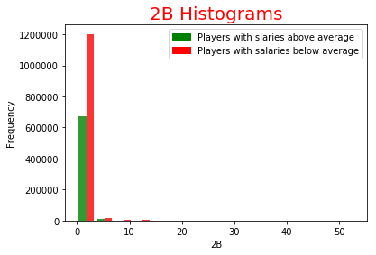

```python
hist_groups(second_merge_1["2B"], second_merge_2["2B"], "2B Histograms", "2B", "Frequency")
```

In this graph, we plot the histograms for both groups together, based on their scores of "2B". The green bins will show the data for the group with salaries above average, and the red bins show the data for the group with salaries below average. Notice that the red bins are higher, because there are more observations in the group with players with salaries below average. Both distributions are right-skewed.

```python
second_merge_1["3B"].describe() #Statistics for "3B" for the group with salaries above average.
```

```
count    688014.000000
mean          0.039011
std           0.312282
min           0.000000
25%           0.000000
50%           0.000000
75%           0.000000
max          13.000000
Name: 3B, dtype: float64
```

```python
second_merge_2["3B"].describe() #Statistics for "3B" for the group with salaries below average.
```

```
count    1.225464e+06
mean     3.665469e-02
std      3.019397e-01
min      0.000000e+00
25%      0.000000e+00
50%      0.000000e+00
75%      0.000000e+00
max      1.300000e+01
Name: 3B, dtype: float64
```

We will compare now the performance of the triples (3B) between the two groups. The mean value of 3B is 0.039 units and standard deviation of 0.312 units for the group of players with salaries above average. The mean value of 3B is 0.037 units and standard deviation of 0.301 units for the group of players with salaries below average. The values range in both groups from 0 to 13 units. There is not much difference in 3B scores between the two groups. Overall, players with salaries above average tend to have higher performance in their doubles (2B). But there is not much difference in performance measured by the triples (3B).

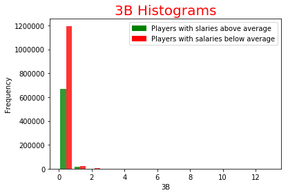

```python
#We plot the histograms of both groups on one graph.
hist_groups(second_merge_1["3B"], second_merge_2["3B"], "3B Histograms", "3B", "Frequency")
```

The interpretation for the graph is similar to the previous one. The red bins represent the data for the group with salaries below average because there are more obervations. Both distributions are right-skewed.

```python
second_merge_1["W"].describe() #Statistics for "W" for the group of players with salaries above average.
```

```
count    688014.000000
mean          7.148936
std           5.779778
min           0.000000
25%           2.000000
50%           6.000000
75%          12.000000
max          27.000000
Name: W, dtype: float64
```

```python
second_merge_2["W"].describe() #Statistics for "W" for the group of players with salaries below average.
```

```
count    1.225464e+06
mean     4.955471e+00
std      4.942478e+00
min      0.000000e+00
25%      1.000000e+00
50%      3.000000e+00
75%      8.000000e+00
max      2.700000e+01
Name: W, dtype: float64
```

Let's compare the pitching results of the groups. We focus on the winning pitches (W) here. The mean score of W is 7.14 units with standard deviation of 5.78 units in the group of players with salaries above average. The mean score of W is 4.95 units with standard deviation of 4.94 units in the groups of players with salaries below average. The values range from 0 to 27 units in both groups. Regarding this measure of performance, we notice that players with salaries above average have more winning pitches on average. This is just observational. We are not claiming that pitching results predict salaries of players.

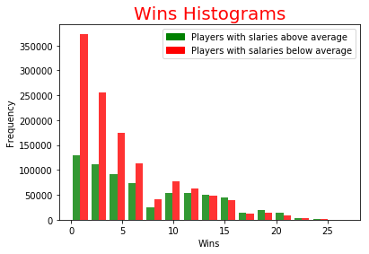

```python
#We plot the histograms of both groups on one graph.
hist_groups(second_merge_1["W"], second_merge_2["W"], "Wins Histograms", "Wins", "Frequency")
```

Notice now that the distribution is slightly different than the previous two. It is still right skewed, but there are more datapoints along the x-axis. Again the red bars represent the data for the group with salaries below average. Hence, they are taller due to more observations.

```python
second_merge_1["L"].describe() #Statistics for "L" for the group of players with salaries above average.
```

```
count    688014.000000
mean          6.019226
std           4.177444
min           0.000000
25%           2.000000
50%           6.000000
75%           9.000000
max          21.000000
Name: L, dtype: float64
```

```python
second_merge_2["L"].describe() #Statistics for "L" for the group of players with salaries below average.
```

```
count    1.225464e+06
mean     4.720827e+00
std      4.134752e+00
min      0.000000e+00
25%      1.000000e+00
50%      4.000000e+00
75%      7.000000e+00
max      2.100000e+01
Name: L, dtype: float64
```

Here we compare the last performance measure we used, i.e. the losing pitches (L). The mean value for "L" is 6.02 units with a standard deviation of 4.18 units for the group with salaries above average. The mean value for "L" is 4.72 units with a standard deviation of 4.13 units for the group with salaries below average. The values range from 0 to 21 units in both groups. In this case, we notice that the players with salaries above average had more losing pitches on average. It could be that the players with highers salaries than average had more games in the year of data collection. And hence they managed to have more losing pitches, along the higher number of winning pitches.

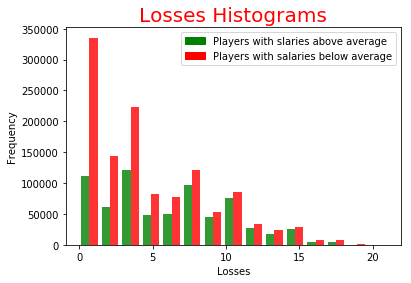

```python
#We plot the histograms of both groups on one graph.
hist_groups(second_merge_1["L"], second_merge_2["L"], "Losses Histograms", "Losses", "Frequency")
```

This distribution is very similar to the previous one. I.e. both histograms are slightly right-skewed. The group with salaries below average had more observations, hence the taller red bins that represent that group.

## Conclusion

In this project we investigated 3 questions. We looked at several relationships between performance measures of baseball players (doubles, triples, winning and losing pitches). We also investigated the relationship of those variables with the salaries of the players. We had all the available data (i.e. no missing values) and the distributions of all the variables were right-skewed. In all cases, the mean was far from the corresponding maximum values, which indicates the presence of outliers. Outliers can be removed from the dataset. However, for the purposes of this project, we wanted to see the distribution of results including all the datapoints. The batting performance measures (doubles and triples) have a positive correlation of 0.656, while the pitching performance measures (winning and losing pitches) have a positive correlation of 0.74. Both of these correlations are rather strong. However, these are just exploratory statistics. These correlations do not imply any causal effect. To detect a causal effect from the performance of doubles on the performance of triples of players for instance, we would need to run a regression analysis while controlling for intervening variables. In the last set of comparisons, we compared the performance measures of players with salaries above average with players with salaries below average. There is a slight difference in performance measured by 2B. Namely, players with salaries above average had higher 2B scores, on average. There was almost no difference in performance measured by 3B. Note that these are exploratory statistics. To definitely claim that there are significant differences in performance measures (2B or 3B) between the players with salaries above and below average, we should run a statistical test. A t-test on difference between means would be appropriate here. Regarding the pitching performance, players with salaries above average had a higher winning score and losing score, on average. The higher winning pitches score might be due to better performance of the players with salaries above average. And the higher losing pitches score might be due to the fact that those players had more games throughout the year of data collection. And hence they managed to accumulate more losses. Nontheless, to claim any conclusion, we should run a t-test on the difference between means of the two groups. If we conclude that we have a significant difference between the performance measures of the two groups, we can run a regression analysis to see how we can predict the salaries of the players based on these variables. Here we looked only at the relationship of 4 perfromance measures with the salaries. There are definitely more possible relationships, which is something that can be looked up in further research.